# Introduction

Course overview and expectations

Trang Tran

2026-09-22

## Self-introduction

- Assistant Professor, Department of System Innovation, University of Tokyo
  - International economics
  - Maritime economics
- Why am I here?
  - Buyout system of the Grant-in-Aid for Scientific Research (S)
  - [“Transformation of the Global Value Chain and the Construction of a New International Economic Order”](https://www.jsps.go.jp/file/storage/kaken_12_g1990/r_6_en_24h00014.pdf)

## Course Content

- What this course covers (trade, ODA, FDI, exchange rates)
- Why Japan? A major economy in the world
- How we’ll learn: lectures, discussion, suggested readings

## Expected Outcomes

- Explain Japan’s role in the global economy.
- Assess Japan’s position in global value chains and its competitiveness.
- Formulate evidence-based perspectives on Japan and current global economic issues.

## Course Map

- Week 1: Introduction (9/22)
- Weeks 2–6: Global value chain
- **Week 7: Group presentation workshop (11/10)**
- Weeks 8-12: ODA, FDI, Exchange Rates
- **Week 13: Final exam (12/22)**
- **Make-up exam (1/19)**

## International Trade

- Japan’s Comparative Advantages
- Measurement of Global Value Chains
- Enablers of Global Value Chains
- Japan and ASEAN
- Geopolitics and Climate Change

## Selected topics on Japanese economy

- Official Development Assistance
- Cross-border investment
- Balance of Payments
- Exchange Rates
- Demographic Challenges and Digitization

## References

- Takatoshi Ito & Takeo Hoshi, 2020, The Japanese Economy (2nd ed.), The MIT Press
- Krugman, P. R., Obstfeld, M., & Melitz, M. J. (2023). International economics: Theory and policy (12th ed.). Pearson.
- 石川城太・椋寛・菊地徹『国際経済学をつかむ』第2版有斐閣

## How We Work

- Class Structure: 20 min short tests + 50 min lecture + 5 min break + 30 min group discussions
- Assessment
  - **Participant**: 10%
  - **Short tests:** 20%
  - **Group presentation workshop:** 30%
  - **Final exam:** 40%
- Voluntary and beneficial remark: one or two pts (maximum 10 pts)
- Points deduction: 5 pts (absent), 3 pts (late)
  - Exceptions include illness or delays in public transportation but with proof is needed
  - If you cheat, you will be kicked out

## Group discussion (first half of the course)

- 7 groups of 5~6 students: register your members by the end of today
- Choose one research question related to the topic of global value chain in two weeks
- Discuss in class
- Presentation (11/10: 10 minutes ~ 5 slides): title, research question + background, evidence, policy implication, conclusion
- Submit of individual report (11/24: 1 A4 page): similar to presentation + what you learn from other groups

### Group discussion (second half of the course)

- Randomly chosen group
- Assigned topics
- Discuss in class

## Classroom management:

- “respon” application: https://univ-gakushuin.respon.jp
- Homework:
  - Prepare for short tests and discussions.
- Office hour: by appointment

## Stats of year 2025

- No of registration: 104
- No of final exam takers: 93
- No of credit eaners: 89
  - S: 4
  - A: 30
  - B: 36
  - C: 19

## Your takeaways

- What interests you in this class ?
- What is your expectation in this class ?

## Japan at a Glance

- High-income
- Economic growth model
- Safe-haven currency
- Aging economy

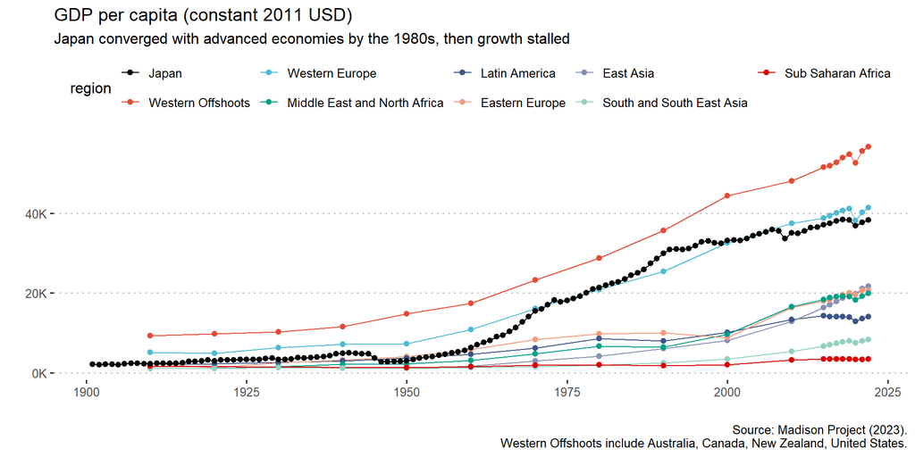

## Growth accounting: the framework

Economic growth comes from two different sources:

- **More inputs**: working more hours, employing more people, building more capital, or having a more educated workforce
- **Using inputs better**: technology, efficiency, and innovation that let the same inputs produce more output (this is called **Total Factor Productivity**, or **TFP**)

## Growth accounting: Japan

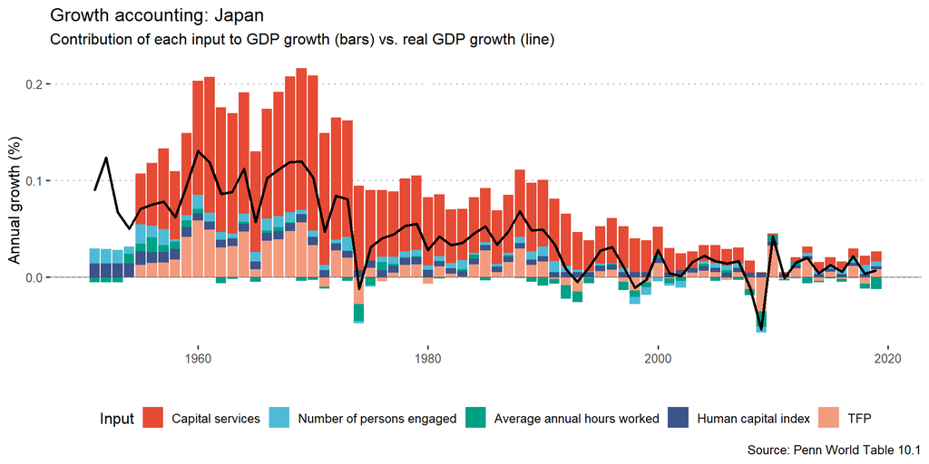

## Growth drivers across countries

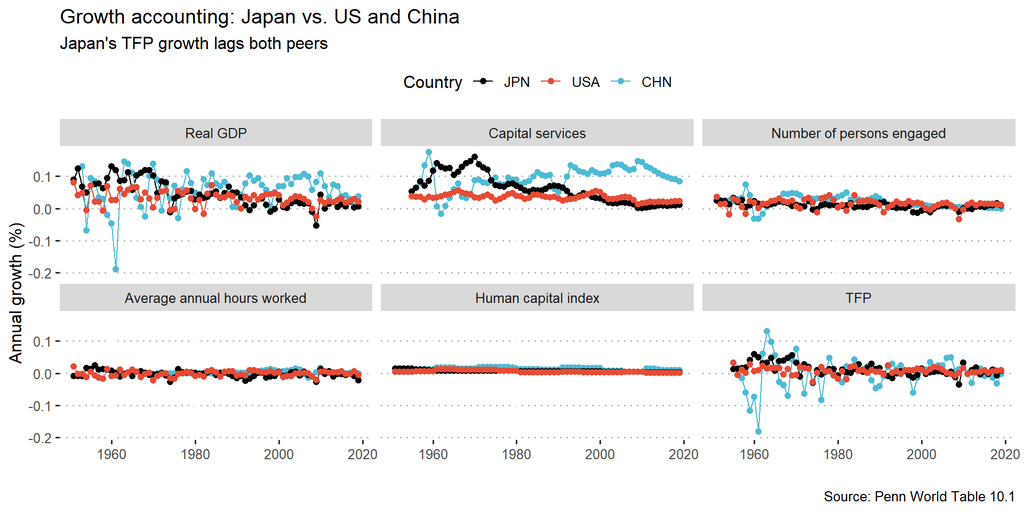

## Export-led growth

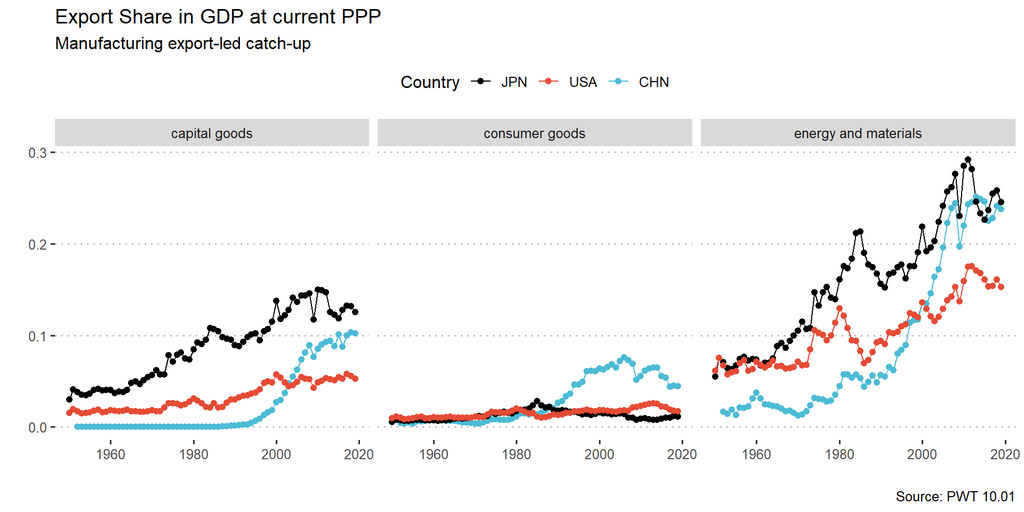

## Structural shift

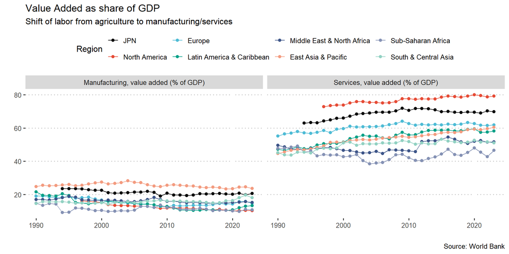

## Role of currency

- **Store of value**: held as reserves by central banks and investors
- **Medium of exchange**: used to invoice and settle cross-border trade, even between two other countries
- **Unit of account**: used to price global assets like oil, or benchmark other currencies against

## Yen as store of value

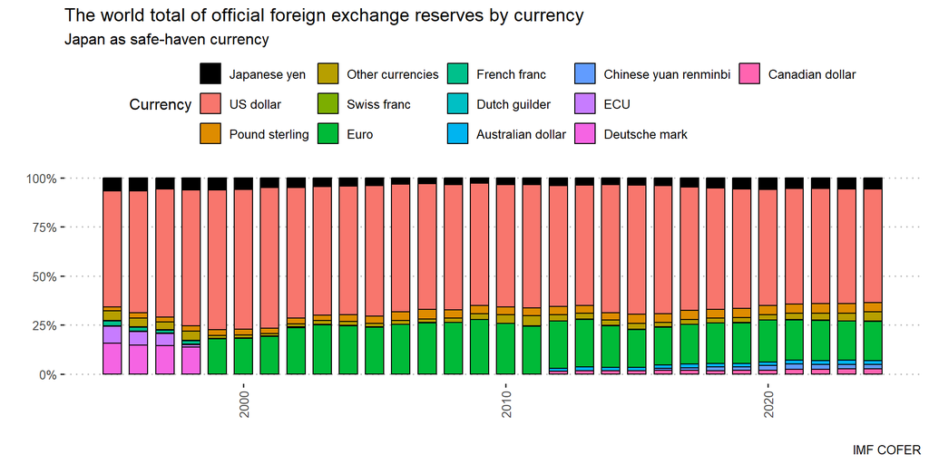

## Why demographics matter

- **Growth drivers**: labor supply directly feeds into the growth accounting framework
- **Market size**: a country’s population sets the scale of domestic demand
- **Consumption**: a population’s age structure drives spending patterns
- **Saving**: national saving rates (working-age people save for retirement; retirees draw savings down)

## Aging economy (population)

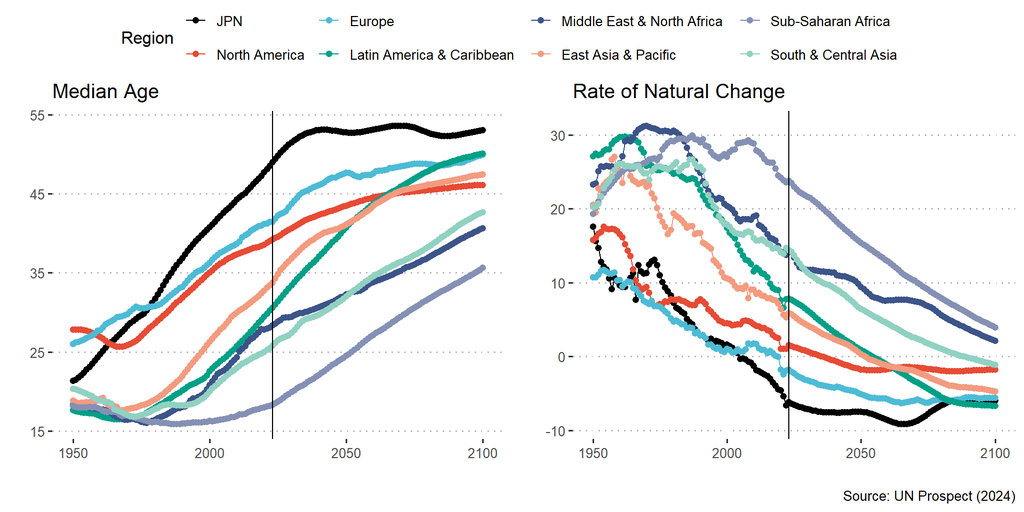

## Aging economy (immigration)

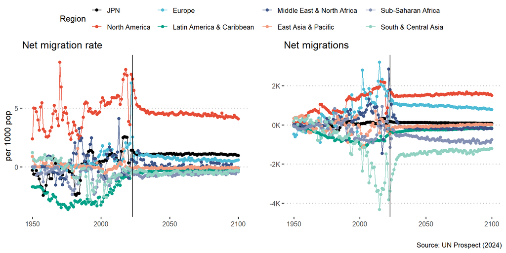

## Japan at a glance: takeaways

- **High-income**: Japan converged with advanced economies decades ago, but stalled since the 1990s
- **Growth model**: Initially investment- and export-led, with rising TFP but since the 1990s, all drivers slowed
- **Safe-haven currency**: the yen has held a stable share of global reserves for decades
- **Aging economy**: a shrinking, aging population is now squeezing the labor input directly

## Suggested Readings

- Ito and Hoshi (2020), chapter 1-3, 12